# Your Digest for Sunday, Sep 24, 2023 11:59 PM

#### Hashimoto thyroiditis (chronic autoimmune thyroiditis)

##### De quervain (subacute thyroiditis)

#2021GM-JUL/Q23

- AKA subacute *granulomatous* thyroiditis, subacute nonsuppurative thyroiditis.
- Presumed to be caused by viral infection or post viral reaction.
- Fundamentaly, a *clinical diagnosis*.
- Neck pain + thyroid tenderness + diffuse goiter usually = subacute thyroiditis.
- Acute thyroid damage -> release of T4 and T3 -> clinical and biochemical hyperthyroidism.
- **Histology**: infiltration with neutrophils and lymphocytes.
- Thyroid uptake scans will show reduced uptake during the hyperthyroid phase.
- **Treatment:** For pain and systemic symptoms: Aspirin / NSAID, failing which prednisolone. Pain should subside in 1 to 2 days.
- **Recovery**: The follicles regenerate and recovery is complete, through a transient hypothyroid stage, upto euthyroidism after a few months.

> [!INFO] Biochemical changes in subacute thyroiditis

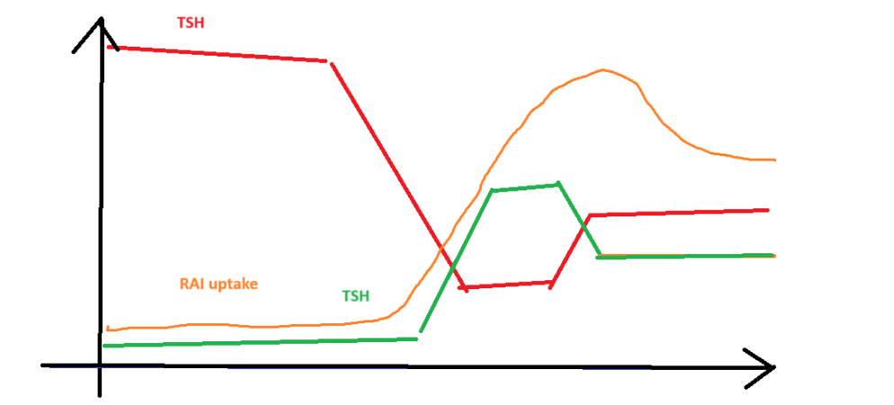

> Adapted from UpToDate
> - At the end of the graph, all 3 parameters return to normal levels.
> - Note the transient **hypothyroid** phase.
> - RAI uptake increase persists for some time after TSH elevation ?probably because the thyroid must restore it's store of thyroid hormones.

# ECG : Lead aVR

Lead aVR is more useful when it's inverted => **-aVR**.
$$
aVR\times-1 = -aVR
$$
-aVR looks at the heart from a view between I and II.

- Normal appearance: aVR looks like an inverted lead II. *All waves are inverted*.
- Therefore, in -aVR, the deflections are upright.  
  Mathematically, it's a graph of the voltage of the right arm with respect to the average of the left arm and left leg.  
  #todo - make a canvas of this part.

# Pleural fluid analysis

#2021GM-JUL/Q30

## Light's criteria

Any **one of the following** indicates that the effusion is **exudative**

- Pleural fluid to serum protein ratio > 0.5;
- Pleural fluid to LDH ratio > 0.6;
- Pleural fluid LDH greater than 2/3 or upper normal limit;

Presumably, light criteria have been derived from observations of levels of LDH.

## Pleural fluid tests

### Elevated pleural LDH is seen in:

1. 1000 IU/L (about x5 of ULN) -
   1. **Empyema**,
   2. rheumatoid pleurisy.
   3. Classically, LDH above 1000 itself indicated IC tube placement but this is not evidence backed.
2. **TB effusions and paraneumonic effusions** - but levels are lower. (frequently > 500 in TB)
3. Pleural to Serum LDH > 1.0 *but* pleural to serum protein < 0.5 is characteristic of *pneumocystis jirovecii*. (and urinothorax)

### Pleural fluid glucose:

- Usually similar to serum glucose.
- **Low in**
  - Rheumatoid pleurisy
  - empyema
  - TB pleurisy
  - Oesophageal rupture
- **High pleural glucose** is only caused by iatrogenic extravasation of some other fluid.

### pH

> [!TIP] Acidotic effusion -> exudate
- Normal pleural pH is estimated to be 7.60.
- Exudates are slightly more acidic (7.30 to 7.45) than transudates (7.4 to 7.55).
- Inadvertent infusion of *normal saline* and *urinothorax* are the only 'transudates' that can have a pleural fluid pH <7.40
- pH below 7.3 is seen in
  - **Lupus pleuritis**
  - **rheumatoid effusion**
  - Parapneumonic effusion and empyema
  - Malignant effusions

### Adenosine deaminase:

> [!INFO] What is adenosine deaminase?  
> Adenosine deaminase is involved in the purine salvage pathway and congenital deficiency of this enzyme leads to accumulation of toxic metabolytes which somehow predomimantly affect lymphocytes leading to the development of one type of severe combined immunodefficiency. (This variety SCID shows autosomal recessive inheritance). The upshot is that it's somehow involved in immune cells which may be why it's found in the effusion fluid in TB.
- Commonest diagnostic test to establish a TB effusion.
- cutoff > 40 IU/L (One uptodate article says 40-70 is 'indeterminate')
- it has a high *negative predictive value* (TB is rare if ADA is < 40)
- Generally considered to have high sensitivity and specificity.
- 'False positives' can occur in empyema, mesothelioma, parapneumonic effusion.

## Pleural fluid cell counts and differential

- Normal pleural fluid contains mostly macrophages and lymphocytes. Total white cell count is < 2000 /microL

# Indications for IC tube

#2021GM-JUL/Q30

> [!TIP] 5 indications for IC tubes  
> Pneumothorax, Trauma, Symptomatic Serous fluid, Non Serous fluid, Surgical
1. Pneumothorax  
   -and Bronchopleural fistula
2. Trauma
   - Penetrating chest trauma
   - Severe blunt chest trauma
3. Non serous fluid
   - Haemothorax
   - Chylothorax
   - Complicated parapneumonic effusion or empyema
4. Serous fluid if symptomatic
   - Symptomatic pleural effusion
5. Surgical procedures
   - Chemical pleurodesis
   - Post op  
     [Source](https://www.ncbi.nlm.nih.gov/pmc/articles/PMC4093965/)

# Posterior myocardial infarction (MI)

#2021GM-JUL/Q21

#2021GM-JUL/Q26

> [!INFO] The facial nerve  
> Components of the nerve:
> - Motor fibers to facial muscles
> - Parasympathetic innervation lacrimal glands, submandibular glands and sublingual glands (but not the parotid gland?)
> - Afferent taste fibers from front 2/3 of the tongue.
> - Somatic afferents from the pinna and external auditory canal.

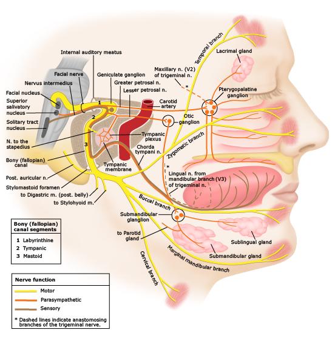

- Bell's palsy is defined as '*idiopathic*' *isolated* facial nerve palsy but a viral (HSV) aetiology is suspected.
  - There is swelling with oedema and inflammatory infiltrate. Damage is greatest in the narrowest part of the passage: the labyrinthine part.
- Accounts for **50% of peripheral facial nerve palsy** with **no age sex prediliction**.
- But there is a x3 risk during T3 of #pregnancy and week 1 post partum.

Basis: swelling of the nerve within the confined petrosal canal due to viral infection or reactivation. (HSV)

- It is clinical diagnosis.
- Symptoms: facial nerve weakness occurring over 1 - 2 days. Hyperacusis, loss of taste of anterior 2/3 of tongue, pain behind the ear, ipsilateral decreased tearing or salivation. There will be *no other systemic signs (eg no rashes or fever)*. Maximum weakness is reached **within 3 weeks** *and then improves* some **improvement is always seen within 4 months** of onset
- facial sensation is intact.

Causes which need to be excluded:

- Local pathology : cholesteotma, malignant otitis media.
- Parotid tumours
- [[2023-SEMPaper#Lyme disease|Lyme Disease]] can cause facial nerve palsy
- HIV seroconversion is **the most common cause** in africa. (because it causes mononeuropathies)
- Herpes zoster oticus (Ramsay hunt syndrome) - diagnosed by ear pain and vessicles in the external auditory meatus.
- Sarcoidosis can cause uni / bi lateral facial nerve palsy.
- Tumours compressing the facial nerve
- Stroke *affecting the **facial nerve nucleus***

## Management and prognosis

- Glucocorticoids within 3 day of onset shortens symptom duration.
- Antivirals are given (specially if weakness if severe) but there is no proven benefit.
- Artificial tears and eye patch to prevent corneal injury. (long term - eye lid weights can be used)
- Synkinesia occurs in 15%. (Involuntary contraction of some facial muscles during voluntary movement of other facial muscles) (can be treated with botulinum toxin)
- 80-85% achieve **full recovery** in *six months*.
- There is a 7% recurrence risk.

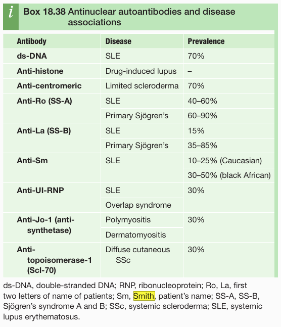

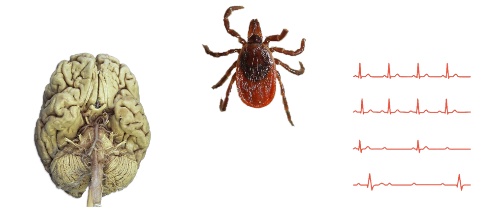

Earliest features is **erythema migrans** - expands to form large red annular lesions.

[figure not shown]

**Mono neuritis multiplex**  
Chronic neurologic involvement - subtle encephalopahty, axonal polyneuropathy,

- What is the relationship between sentivity and positive / negative predictive value?

# Scratch pad:

The ventricular wall and the associated leads are shown here:

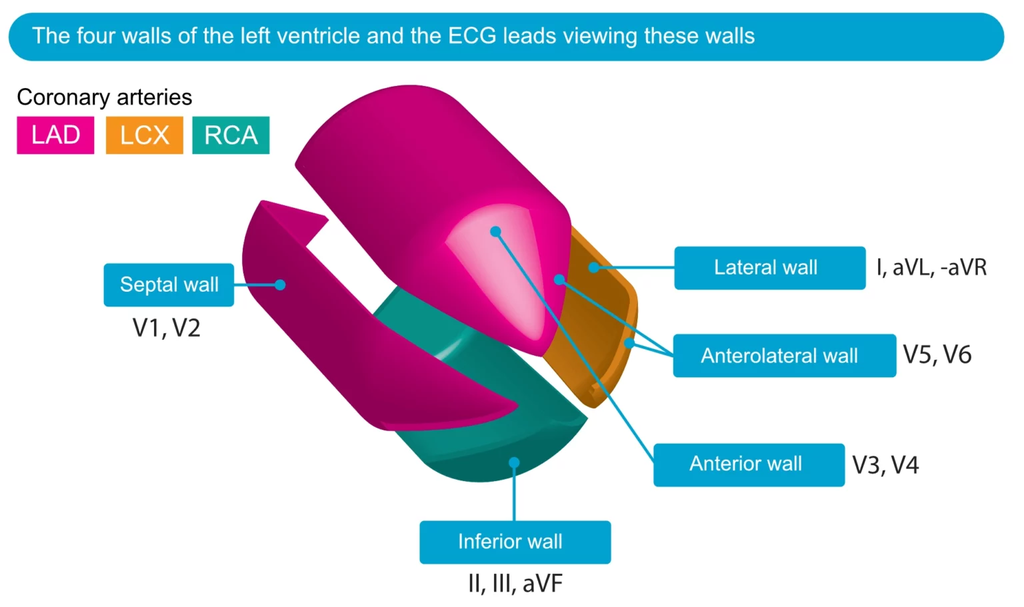

- **V1-V2** (“septal leads”): primarily observes the ventricular septum, but may occasionally display ECG changes originating from the right ventricle. Note that none of the leads in the 12-lead ECG are adequate to detect vectors of the right ventricle.
- **V3-V4** (“anterior leads”): observes the anterior wall of the left ventricle.
- **V5-V6** (“anterolateral leads”): observes the lateral wall of the left ventricle.
- **V7,V8,V9** - posterior leads.

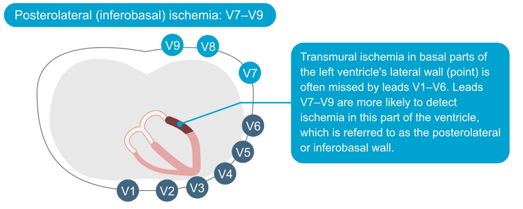